# DATA 624: Homework 6

Andrew Bowen

2024-03-03

## Exercise 9.2

First let’s plot the amazon closing stock price time series:

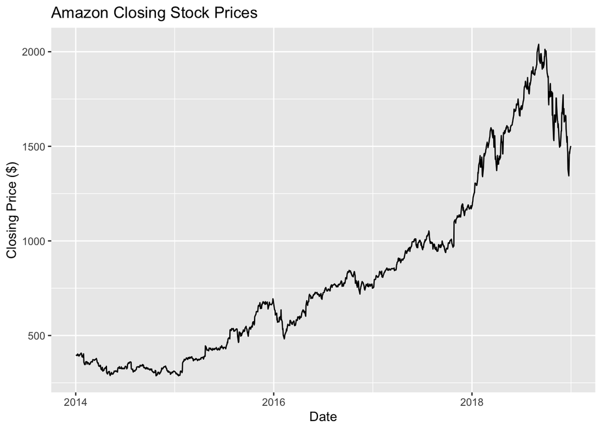

```r
amazon <- gafa_stock %>% filter(Symbol == "AMZN")

amazon %>% autoplot(Close)  +
  labs(x = "Date", y="Closing Price ($)", title="Amazon Closing Stock Prices")
```

This plot is non stationary because the level of the time series changes with time, so properties of the time series (in this case, the level) *do* depend on time.

Now we can plot the ACF and PACF of this time series

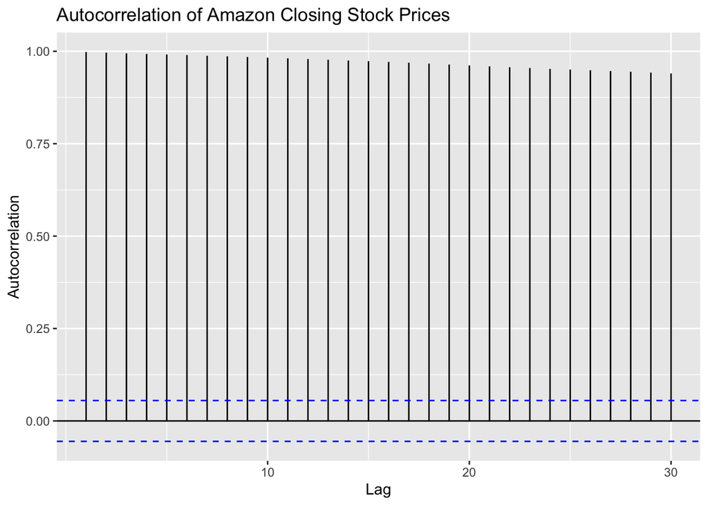

```r
amazon |> ACF(Close) |>
  autoplot() + labs(x = "Lag", y="Autocorrelation", title="Autocorrelation of Amazon Closing Stock Prices")
```

In this case, we see stroong autocorrelation (above the threshold) for all lags, indicating a non-stationary time series. This validates what we saw above in the simple time series plot

No we can plot the partial autocorrelation function (PACF) plot

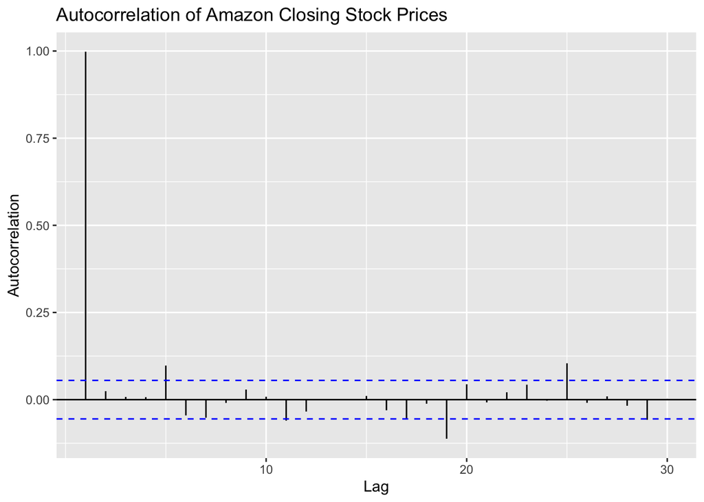

```r
# Plot PACF
amazon %>% PACF(Close) %>%
  autoplot() + labs(x = "Lag", y="Autocorrelation", title="Autocorrelation of Amazon Closing Stock Prices")
```

In a partial autocorrelation function plot, the lags prior to a given lag period are removed. In this case, we see a strong correlation with a lag $k=1$, which makes sense given the strong trend int his time series. Besides that, there are some stronger autocorrelations at $k = 5, 19, 25$, but fewer lags whihc would be considered statistically significant. In this case, we’re still observing non-stationarity, given the autocorrelations present, but this plot presents a cleaner picture.

## Exercise 9.3

#### Turkish GDP

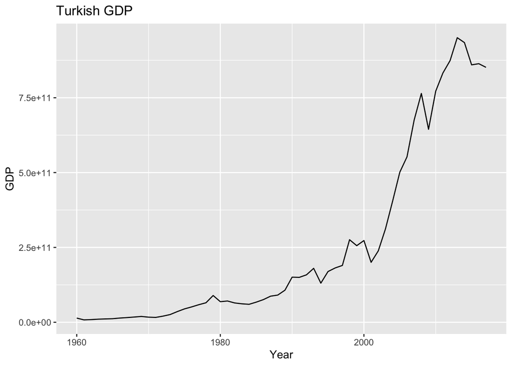

```r
# First set up our turkish time series
turkey <- global_economy %>% filter(Country == "Turkey")

turkey %>% autoplot(GDP) +
  labs(x="Year", y="GDP", title="Turkish GDP")
```

There isn’t much seasonality here, but there is a strong upwards trend, especially after 1990.

```r
lambda_turkey <- turkey |> features(GDP, features = guerrero) |>
  pull(lambda_guerrero)
# Print out optimal lambda value
print(lambda_turkey)
```

```
## [1] 0.1572187
```

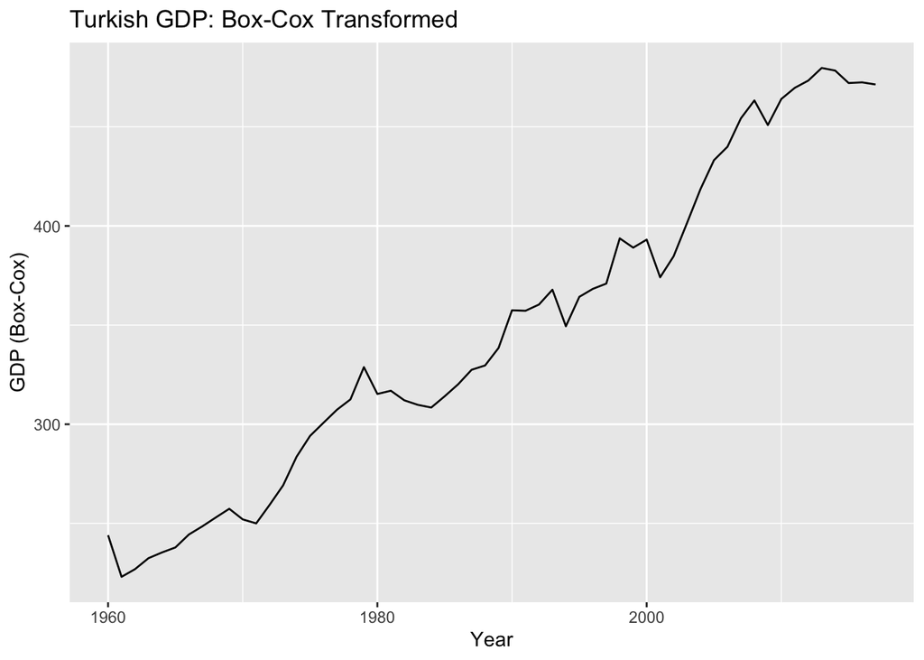

```r
turkey$GDP_transformed <- box_cox(turkey$GDP, lambda_turkey)

turkey %>% autoplot(GDP_transformed) +
  labs(x="Year", y="GDP (Box-Cox)", title="Turkish GDP: Box-Cox Transformed")
```

Now we can use differencing to stabilize the mean of our time series

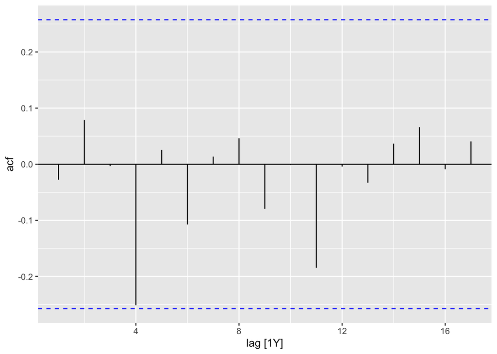

```r
turkey$GDP_diff <- difference(turkey$GDP_transformed)
turkey %>% ACF(difference(GDP_transformed)) %>% autoplot()
```

With a differencing of our box-cox transformed GDP data, we see no autocorrelation now

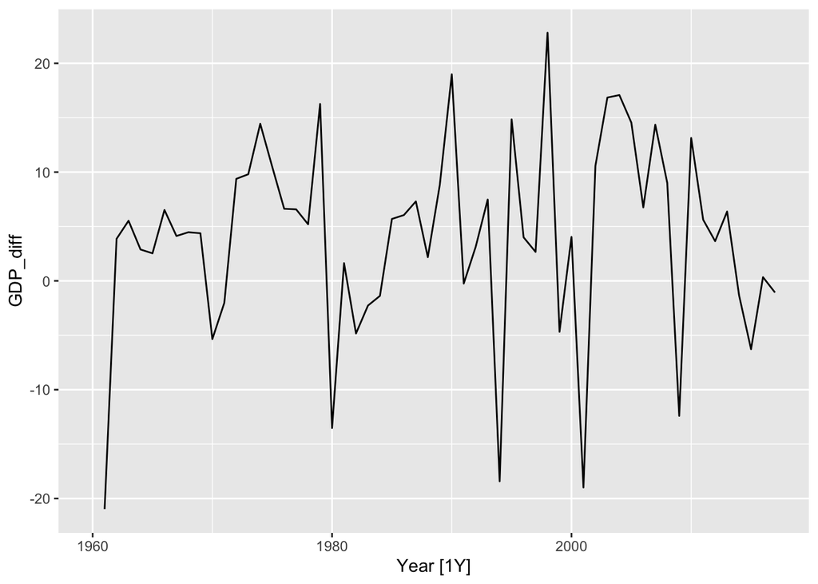

```r
turkey %>% autoplot(GDP_diff)
```

Visually, this looks to be much more stationary data!

#### Tasmanian Accomodations

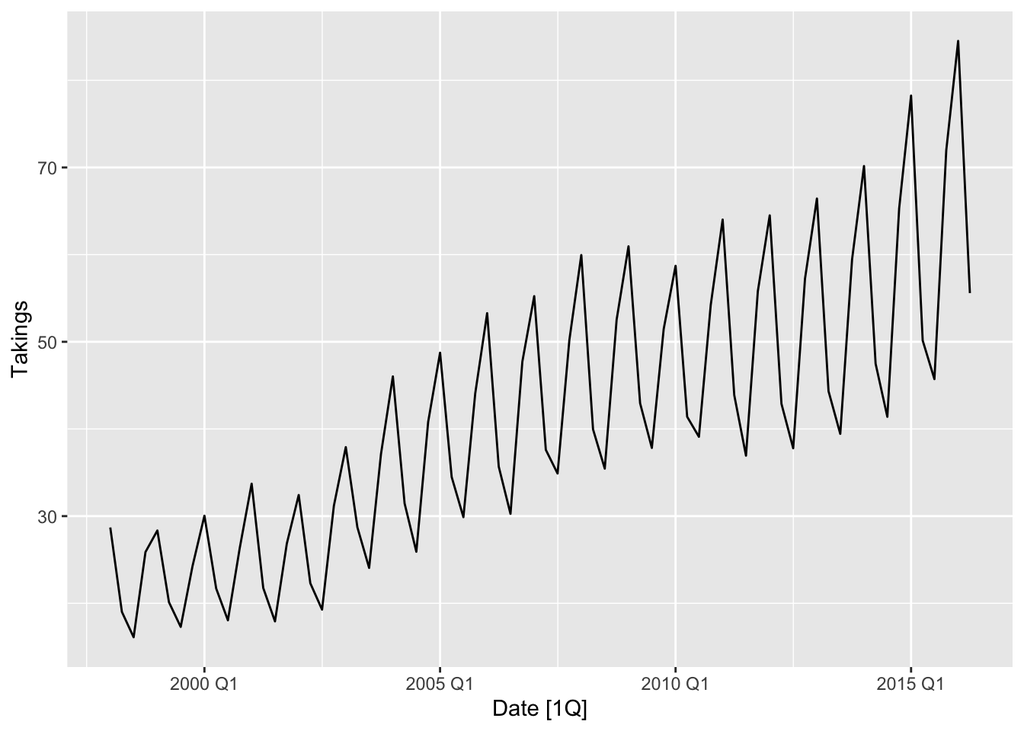

```r
tasmania <- aus_accommodation %>% filter(State == "Tasmania")

tasmania %>% autoplot(Takings)
```

Given this time series’ variance with time, we’ll want to undergo a Box-cox transformation to reduce that variance over time

```r
lambda_tasmania <- tasmania |> features(Takings, features = guerrero) |>
  pull(lambda_guerrero)
# Print out optimal lambda value
print(lambda_tasmania)
```

```
## [1] 0.001819643
```

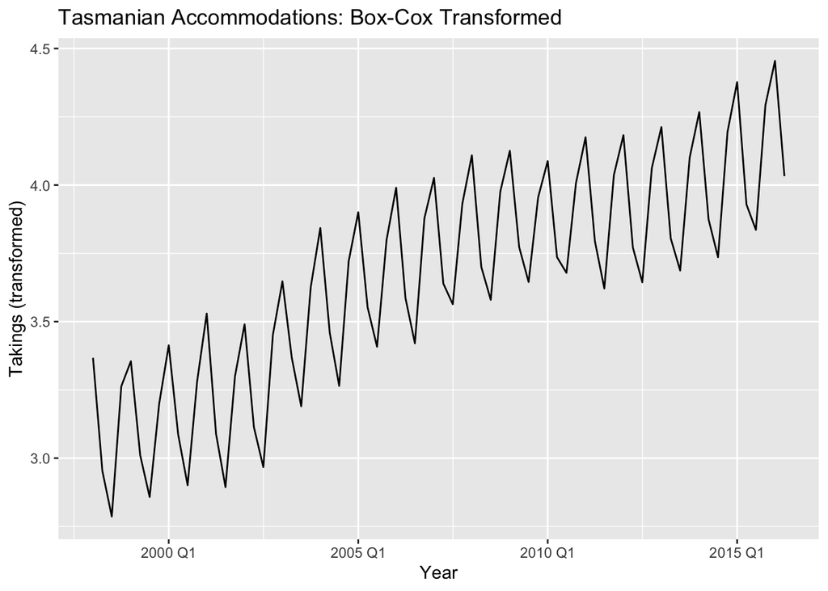

```r
tasmania$Takings_transformed <- box_cox(tasmania$Takings, lambda_tasmania)

tasmania %>% autoplot(Takings_transformed) +
  labs(x="Year", y="Takings (transformed)", title="Tasmanian Accommodations: Box-Cox Transformed")
```

This helps to even out the level of the variance with time, now we can apply differencing to get stationary data

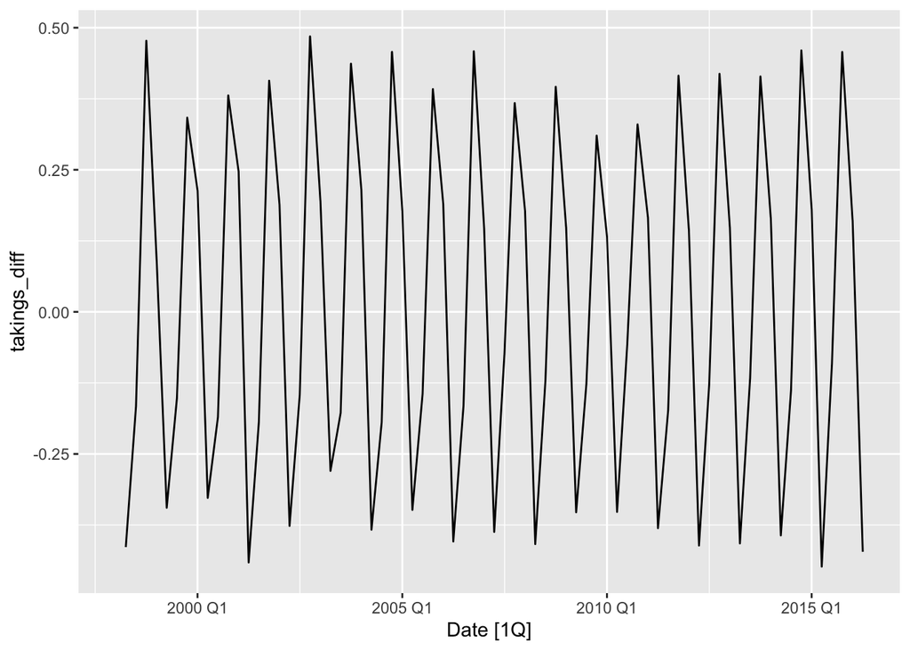

```r
tasmania$takings_diff <- difference(tasmania$Takings_transformed)

# Plot differenced data
tasmania %>% autoplot(takings_diff)
```

This data looks much more stationary, which we want!

#### Souvenir Sales

First, let’s plot the monthly souvenir sales data

```
## Plot variable not specified, automatically selected `.vars = Sales`
```

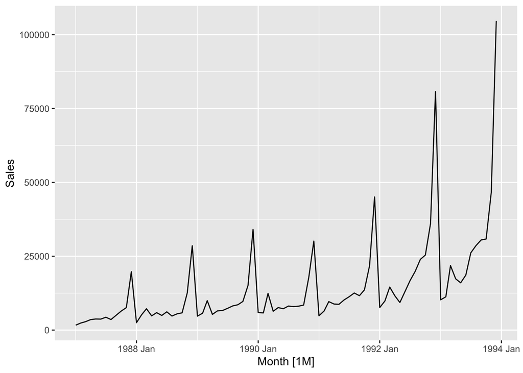

```r
souvenirs %>% autoplot()
```

Again, the level of variance for this time series does change with time, so we’ll have to apply a transformation, we’ll use Box-Cox

```r
lambda_souvenir <- souvenirs |> features(Sales, features = guerrero) |>
  pull(lambda_guerrero)
# Print out optimal lambda value
print(lambda_souvenir)
```

```
## [1] 0.002118221
```

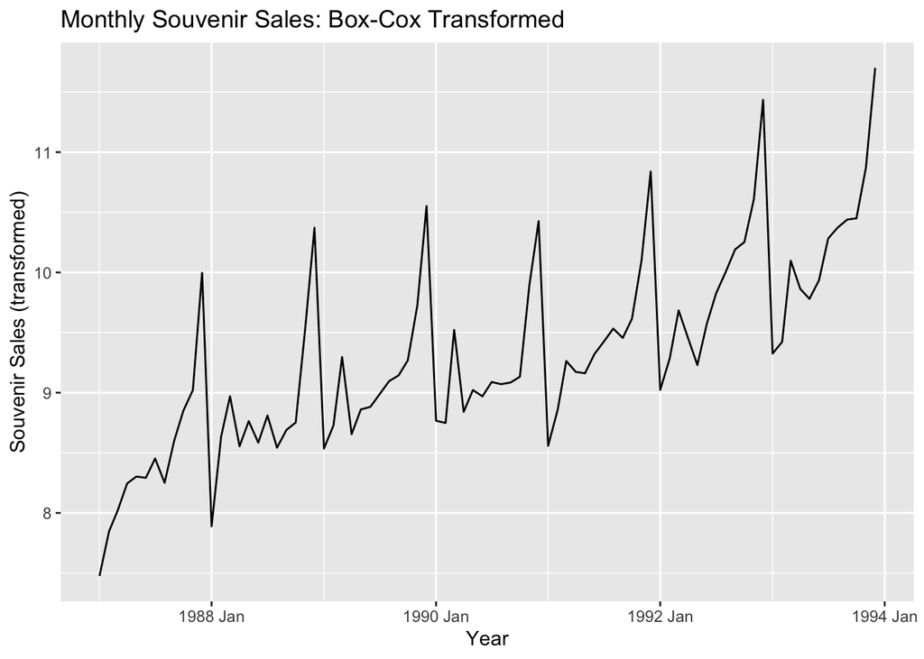

```r
souvenirs$sales_transformed <- box_cox(souvenirs$Sales, lambda_souvenir)

souvenirs %>% autoplot(sales_transformed ) +
  labs(x="Year", y="Souvenir Sales (transformed)", title="Monthly Souvenir Sales: Box-Cox Transformed")
```

Now we’ll apply differencing to the box-cox transformed souvenir sales data

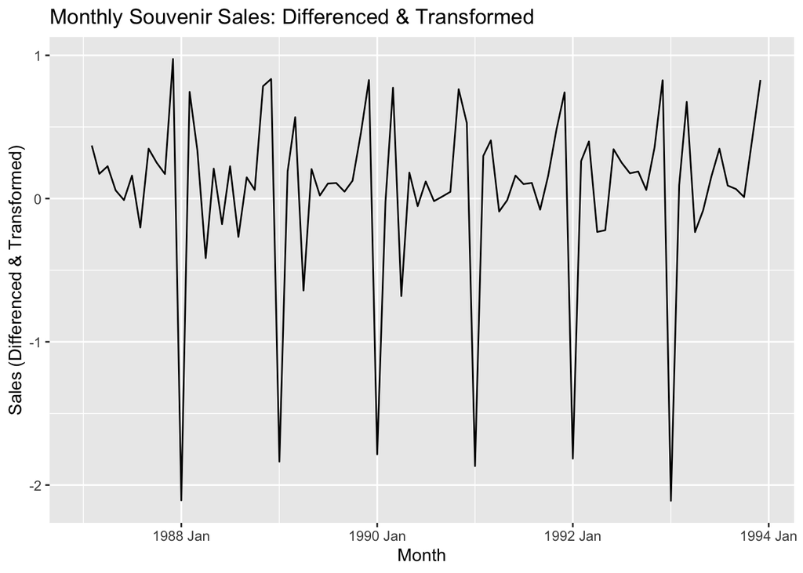

```r
souvenirs$sales_diff <- difference(souvenirs$sales_transformed)

# Plot differenced data
souvenirs %>% autoplot(sales_diff) + labs(x="Month", y="Sales (Differenced & Transformed)", title="Monthly Souvenir Sales: Differenced & Transformed")
```

## Exercise 9.5

First, let’s set up the time series from [Exercise 2.7](https://otexts.com/fpp3/graphics-exercises.html#graphics-exercises)

```
## Plot variable not specified, automatically selected `.vars = Turnover`
```

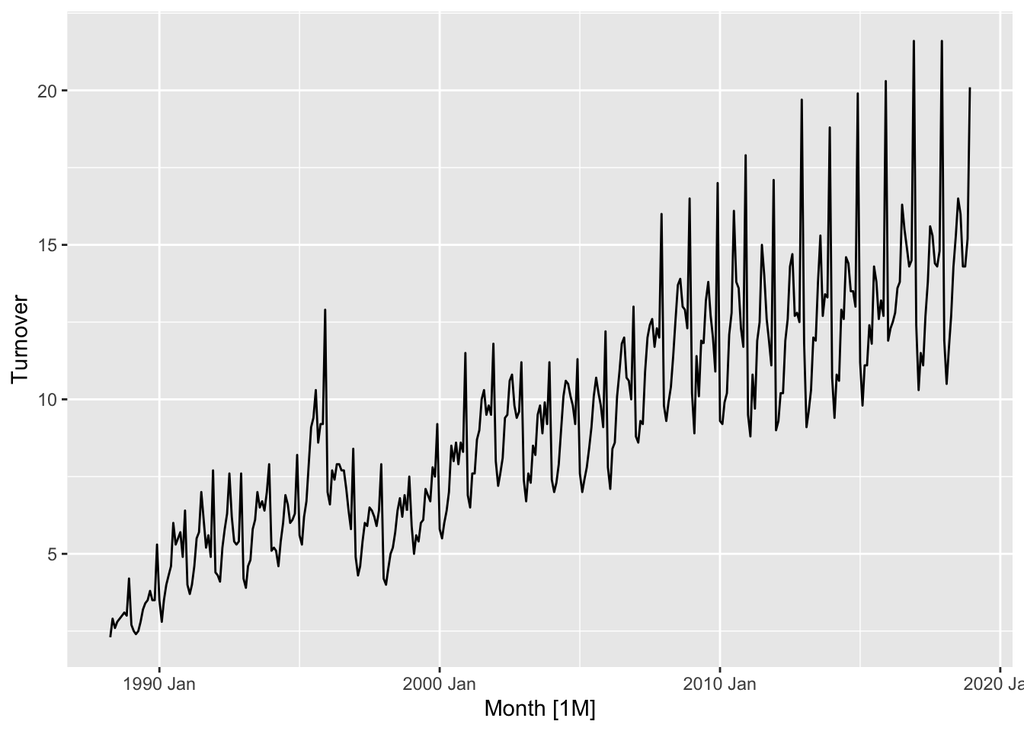

```r
set.seed(12345678)
myseries <- aus_retail |>
  filter(`Series ID` == sample(aus_retail$`Series ID`,1))

myseries %>% autoplot()
```

Given the variance of our seasonal changes is not constant, we’ll likely need to transform this data *before* differencing. In this case, let’s try a simple logarithm transformation

Now, let’s apply both seasonal differencing and double differencing (applied to seasonally differenced data). We’ll mirror the [method used in Hyndman to create our plots](https://otexts.com/fpp3/stationarity.html#seasonal-differencing)

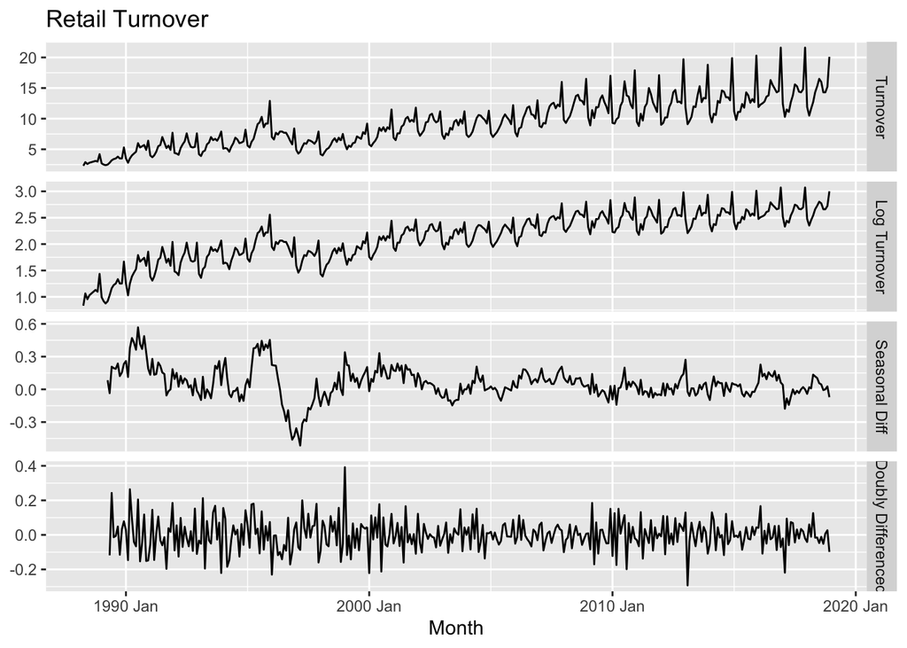

```r
myseries %>%
  transmute(
    `Turnover` = `Turnover`,
    `Log Turnover` = log(Turnover),
    `Seasonal Diff` = difference(log(Turnover), 12),
    `Doubly Differenced` =
                     difference(difference(log(Turnover), 12), 1)
  ) |>
  pivot_longer(-Month, names_to="Type", values_to="Turnover") |>
  mutate(
    Type = factor(Type, levels = c(
      "Turnover",
      "Log Turnover",
      "Seasonal Diff",
      "Doubly Differenced"))
  ) |>
  ggplot(aes(x = Month, y = Turnover)) +
  geom_line() +
  facet_grid(vars(Type), scales = "free_y") +
  labs(title = "Retail Turnover", y = NULL)
```

The double-differencing plot appears to be the most stationary, so a differencing order of 2 seems to be appropriate here.

## Exercise 9.6

```r
# Code form Hyndman
y <- numeric(100)
e <- rnorm(100)
for(i in 2:100)
  y[i] <- 0.6*y[i-1] + e[i]
sim <- tsibble(idx = seq_len(100), y = y, index = idx)
```

```
## Plot variable not specified, automatically selected `.vars = y`
```

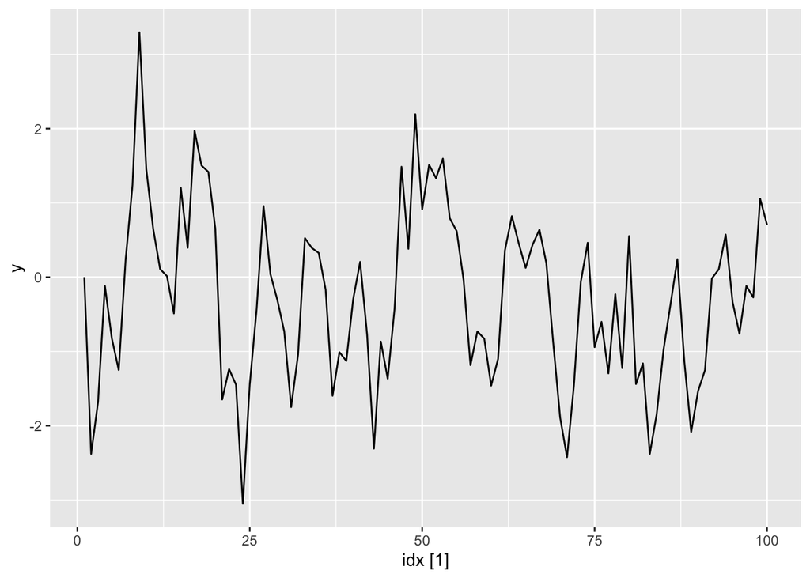

```r
# Plot time plot
sim %>% autoplot()
```

Let’s alter our value to be $\phi_1 = 0.95$ value to see how that changes the plot

```
## Plot variable not specified, automatically selected `.vars = y`
```

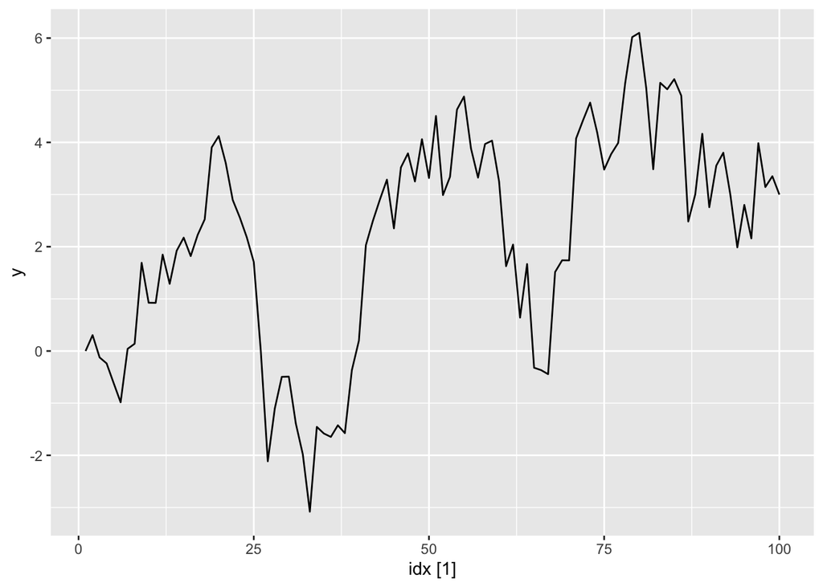

```r
y <- numeric(100)
e <- rnorm(100)
for(i in 2:100)
  y[i] <- 0.95*y[i-1] + e[i]
sim <- tsibble(idx = seq_len(100), y = y, index = idx)
sim %>% autoplot()
```

Here we see bigger variations and data that could quite possibly not be stationary.

```
## Plot variable not specified, automatically selected `.vars = y`
```

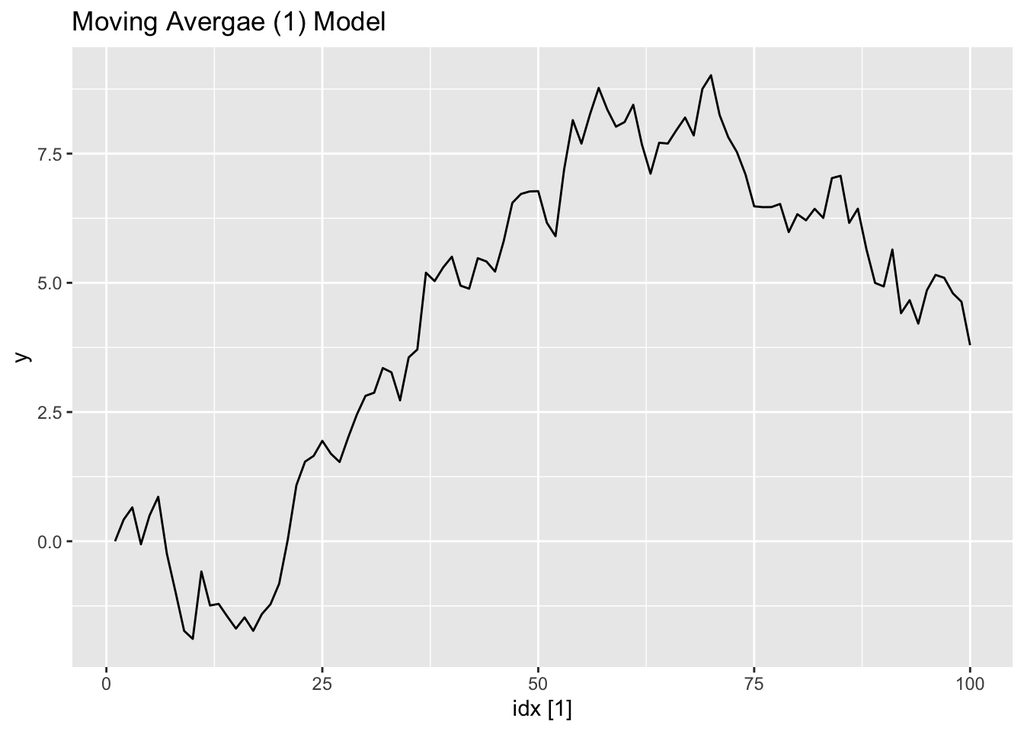

```r
# Custom MA(1) model
y <- numeric(100)
e <- rnorm(100)
theta <- 0.6
for(i in 2:100)
  y[i] <- y[i-1] + theta * e[i]
sim <- tsibble(idx = seq_len(100), y = y, index = idx)
sim %>% autoplot() + labs(title="Moving Avergae (1) Model")
```

Now let’s try a different value for $\theta_1 = 0.8$

```
## Plot variable not specified, automatically selected `.vars = y`
```

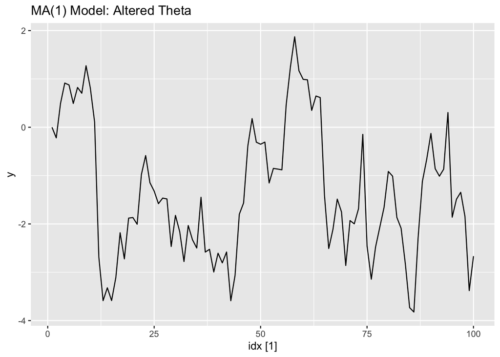

```r
y <- numeric(100)
e <- rnorm(100)
theta <- 0.8
for(i in 2:100)
  y[i] <- y[i-1] + theta * e[i]
sim <- tsibble(idx = seq_len(100), y = y, index = idx)
sim %>% autoplot() + labs(title="MA(1) Model: Altered Theta")
```

```
## Plot variable not specified, automatically selected `.vars = y`
```

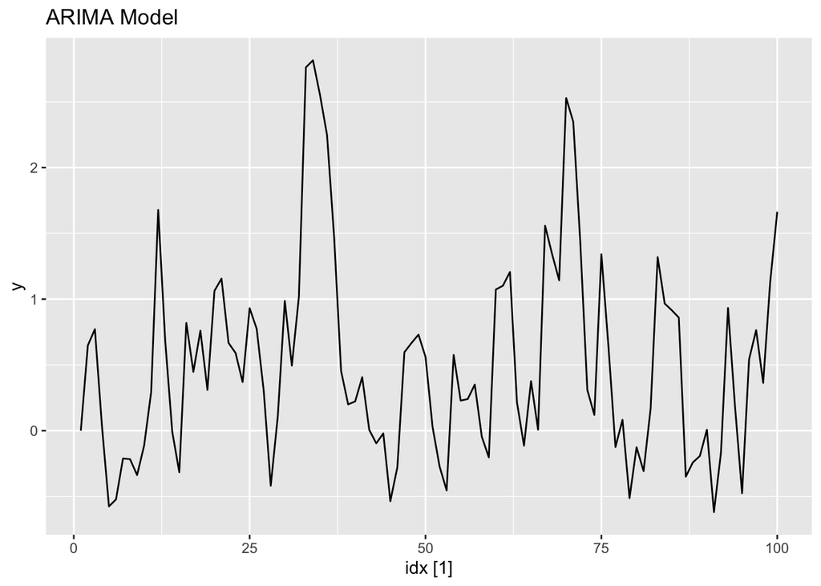

```r
y <- numeric(100)
e <- rnorm(100)
theta <- 0.6
phi <- 0.6
for(i in 2:100)
  y[i] <- phi * y[i-1] + theta * e[i]
sim <- tsibble(idx = seq_len(100), y = y, index = idx)
sim %>% autoplot() + labs(title="ARIMA Model")
```

```
## Plot variable not specified, automatically selected `.vars = y`
```

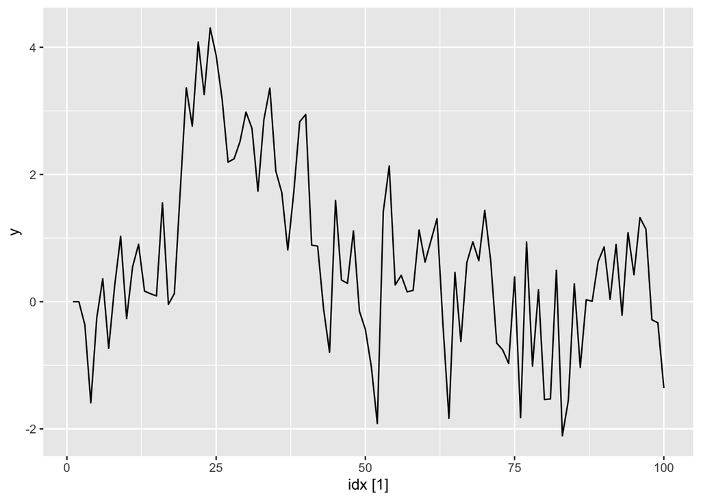

```r
y <- numeric(100)
e <- rnorm(100)
phi_1 <- 0.6
phi_2 <- 0.3
for(i in 3:100)
  y[i] <- phi_1 * y[i-1] + phi_2 * y[i - 2]  + e[i]
sim <- tsibble(idx = seq_len(100), y = y, index = idx)

sim %>% autoplot()
```

## Exercise 9.7

We’ll let ARIMA select parameters for the `aus_airpassengers` time series

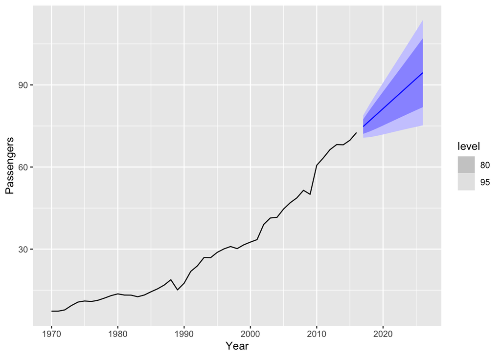

```r
# Allow ARIMA to select parameters
aus_fit <- aus_airpassengers %>% model(ARIMA(Passengers))

aus_fit %>% forecast(h=10) %>% autoplot(aus_airpassengers)
```

Where $\epsilon_t$ is our error (white noise) and [B is the backshift operator](https://otexts.com/fpp3/backshift.html) ($By_t = y_{t-1}$). When expanded out, we get the equation:

$$\begin{aligned}
0 = y_t(1 + \theta B^3 - \theta B - B^2) + \epsilon_t \newline
= y_t - \theta y_{t-3} - \theta y_{t-1} - y_{t-2} + \epsilon_t
\end{aligned}$$

## Exercise 9.8